# Лабораторная работа №1

Подготовка стенда и модель экспоненциального роста

Бахарев Дмитрий Александрович

traap.luuvv@mail.ru

Российский университет дружбы народов

# Введение

## Актуальность

- Имитационное моделирование — универсальный инструмент в естественных и технических науках.
- Модель экспоненциального роста — базовый пример динамической системы.
- Освоение Julia/DrWatson/Literate/Quarto необходимо для воспроизводимых исследований.

## Цель и задачи

**Цель:** освоить инструменты Julia/DrWatson/Literate/Quarto и исследовать модель экспоненциального роста.

**Задачи:**

1. Создать рабочее пространство курса.
2. Установить пакеты Julia.
3. Реализовать модель экспоненциального роста.
4. Провести параметрическое исследование.
5. Собрать отчёт в формате PDF/DOCX.

# Теоретическая часть

## Модель экспоненциального роста

Уравнение:

$$\frac{du}{dt} = \alpha u, \quad u(0) = u_0.$$

Аналитическое решение:

$$u(t) = u_0 e^{\alpha t}.$$

Время удвоения:

$$T_2 = \frac{\ln 2}{\alpha}.$$

## Инструменты

| Инструмент | Назначение |
| --- | --- |
| Git + Gitflow | Контроль версий |
| Julia | Язык научных вычислений |
| DrWatson.jl | Организация проектов |
| Literate.jl | Литературное программирование |
| Quarto | Сборка отчётов PDF/DOCX |

# Выполнение лабораторной работы

## Создание рабочего пространства

Рабочий каталог курса создан на основе шаблона. Проект DrWatson инициализирован в каталоге `labs/lab01/project` (рис. 1).

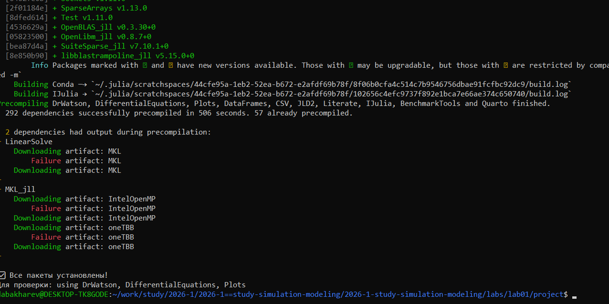

## Установка пакетов

Пакеты Julia успешно установлены и проверены (рис. 2).

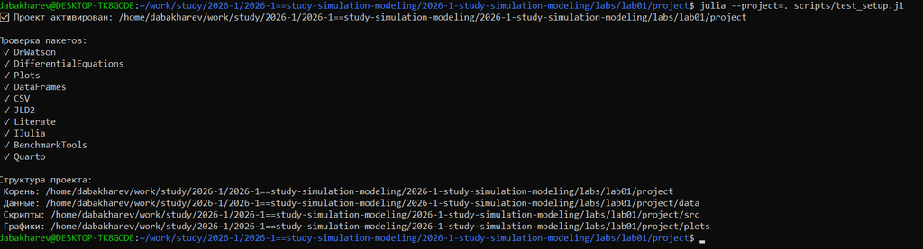

Установка и проверка пакетов

## Код скриптов

[figure not shown]

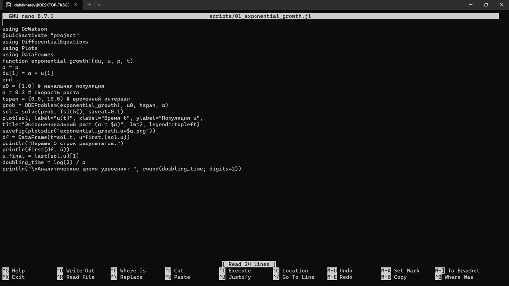

## Результаты: базовый случай

График численного решения для $\alpha = 0.3$ приведён на рис. 5.

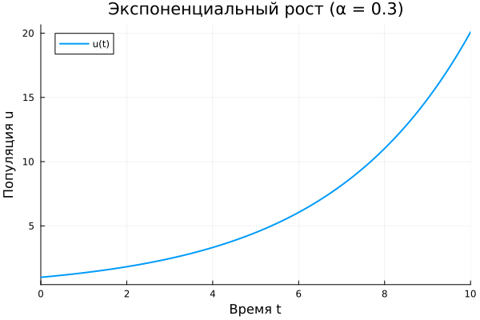

Численное решение модели экспоненциального роста

## Результаты: параметрическое исследование

Сравнение траекторий для разных $\alpha$ показано на рис. 6.

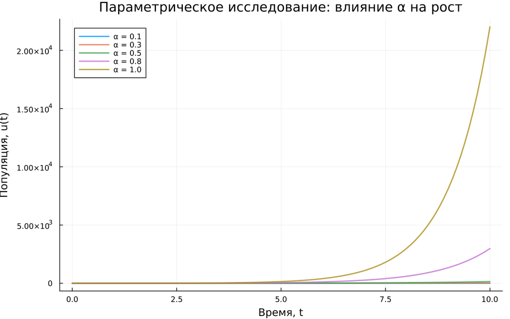

Сравнение траекторий

## Jupyter-ноутбук

Jupyter-ноутбук с параметрическим исследованием выполнен (рис. 7).

[figure not shown]

Выполнение ноутбука

# Заключение